# Introduction to BayesMultiomics Package

## 1. Purpose

In the first stage, we use Expectation Maximization based approach to learn the regulating mechanism between epigenomics (e.g., gene methylation) and gene expression while considering functional gene annotations. In the second stage, we group genes based on the regulating mechanism learned in the first stage. Then, we apply a group-wise penalty to select genes significantly associated with clinical outcomes while incorporating clinical features.

## 2. Algorithms

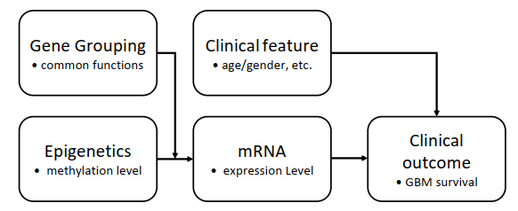

Baisc workflow

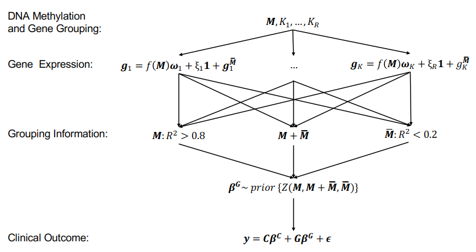

Model diagram

## 4. David functional classifcation tool

`vignette("gene_grouping")`

Once the classification file is downloaded as txt, use `DAVIDGeneGrouping()` function to obtain the gene grouping.

```r
fp <- system.file("eg_fx_classification.txt", package="BayesMultiomics")
gene_grouping <- DAVIDGeneGrouping(eg_gene_symbols, fp)
gene_grouping
```

[output not shown]

## 5. First Stage Data Integration Model (FSDIM)

In the first stage, we will combine information from methylation, gene expression, and gene function annotation data to group genes based on how their expressions are regulated by DNA methylation.

FSDIM aims to combine information from methylation `M`, gene expression `G`, and gene function annotation data (functional classification) to group genes based on how their expressions are regulated by DNA methylation. Essentially, Essentially, we divide the given K genes into three groups: (1) genes that are modulated by only DNA methylation (M type effect); (2) genes that are modulated by aspects other than DNA methylation (M¯ type effect); (3) genes that are modulated jointly by DNA methylation and aspects other than DNA methylation.Genes will be assigned group membership depending on the coefficient of determination, R2 of FSDIM.

The functional classification used in FDSIM is obtained from Database for Annotation, Visualization, and Integrated Discovery ([DAVID](https://david.ncifcrf.gov)).

```r
# example data
M <- GBM_data2$M
G <- GBM_data2$G

FSDIM_result <- FSDIM(M, G, gene_grouping, I=10, thresh=0.001)
```

Classify genes into 3 groups using `Zmat_builder`

## 6. Second Stage Data Integration Model (SSDIM)

SSDIM is a linear model that can be used to detect biomarkers associated with the clinical outcome `Y` of interest while considering the knowledge learned from FSDIM. It regresses clinical outcome of interest on relevant clinical features `C` and gene expression `G`, regularized with a group penalty reflecting methylation regulating mechanism and gene functional similarity learned from FSDIM. In this way, the SSDIM further integrates clinical outcomes to develop a unified way of combining and curating the set of predictor variables with the clinical responses.

```r
G <- GBM_data2$G
Y <- GBM_data2$Y
C <- GBM_data2$C
R2 <- FSDIM_result$R2
Zmatrix <- Zmat_builder(R2, G, 0.2, 0.8)
mpmath <- setup_mpmath()
a0 <- 0.1
gstr <- "scale"

SSDIM_result <- SSDIM(Y, G, C, a0, gstr, Zmatrix,
                      I=10, thresh=0.001, .mpmath=mpmath)
```

## 7. Data Analysis with `Bayesmultiomics`

`BayesMultiomics` function puts together the first and second stage models and performs the entire algorithm. The output summarizes 1) selected genes from the first stages modeling, 2) gene functional classificaiton groups and methylation groups; 3) coefficients of the clinical features and selected genes. `BayesMultiomics.CV` is an extended version `BayesMultiomics` where the performance of models are evaluated using K-fold cross validation. `BayesMultiomicsPriorSensitivity` function performs the same tasks over a range of values of priors `a` and `g`.

Example with `BayesMultiomics`

```r
M <- GBM_data2$M
G <- GBM_data2$G
fp <- system.file("eg_fx_classification.txt", package="BayesMultiomics")
gene_grouping <- DAVIDGeneGrouping(eg_gene_symbols, fp)
Y <- GBM_data2$Y
C <- GBM_data2$C
a0 <- 0.1
gstr <- "scale"
mpmath <- setup_mpmath()

# run
multiomics <- BayesMultiomics(
  M=M,
  G=G,
  grouping=gene_grouping,
  Y=Y,
  C=C,
  a0=a0,
  gstr=gstr,
  EMVS_I = 10,
  NEG_I= 10,
  EMVS_thresh = 0.0001,
  NEG_thresh = 0.0001,
  transform_M = "L",
  lower_R2 = 0.2,
  upper_R2 = 0.8,
  .mpmath = mpmath
)
```

```r
# summaries
print(multiomics)
```

```
#> $Genes
#>   gene_name   coeff methylation_group functional_group
#> 1    SEMA3E -1.6257                 M               30
#> 2   RANBP17  3.6941             joint               30
#> 3       IL8 -2.9560                 M               30
#> 4      CBR1 -7.3808              nonM               30
#> 5     DDIT4  5.8269              nonM               30
#> 6    HAPLN1  2.8052                 M               22
#>
#> $`Clinical Variables`
#>      clinical_variable   coeff
#> 1                  AGE  0.3007
#> 2         PRIOR_GLIOMA  9.9836
#> 3                  SEX  0.2674
#> 4 PRETREATMENT_HISTORY 19.1486
```

Example on `BayesMultiomics.CV`

```r
M <- GBM_data2$M
G <- GBM_data2$G
fp <- system.file("eg_fx_classification.txt", package="BayesMultiomics") # replace with your own file path
gene_grouping <- DAVIDGeneGrouping(eg_gene_symbols, fp)
Y <- GBM_data2$Y
C <- GBM_data2$C
a0 <- 0.1
gstr <- "scale"
Delta <- GBM_data2$Delta

# run
multiomics_cv <- BayesMultiomics.CV(
  M=M,
  G=G,
  grouping=gene_grouping,
  Y=Y,
  C=C,
  a0=a0,
  gstr=gstr,
  Delta=Delta,
  n_fold=10,
  random_seed = 123,
  EMVS_I = 10,
  NEG_I=20,
  EMVS_thresh = 0.0001,
  NEG_thresh = 0.0001
  )
```

```r
print(multiomics_cv)
```

```
#> $performance
#>                 average of 10-fold
#> prior_a         "0.1"
#> prior_g         "scale"
#> n_selected_vars "4.9"
#> r2_train        "0.4462951"
#> r2_test         "0.2820807"
#> cindex_train    "0.603808"
#> cindex_test     "0.5694689"
#> mse_train       "241.2258"
#> mse_test        "358.8711"
#>
#> $`Clinical Variables`
#>      clinical_variable   coeff
#> 1                  AGE  0.3008
#> 2         PRIOR_GLIOMA  6.6989
#> 3                  SEX  0.0631
#> 4 PRETREATMENT_HISTORY 20.6203
#>
#> $Genes
#>   gene_name   coeff methylation_group functional_group
#> 1    SEMA3E -1.1192                 M               30
#> 2   RANBP17  5.1743             joint               30
#> 3       IL8 -1.8387                 M               30
#> 4      CBR1 -3.8227              nonM               30
#> 5    HAPLN1  1.4706                 M               25
#> 6     SNX10 -1.4528             joint               30
#> 7     DDIT4  3.7527              nonM               30
#> 8      PDPN -0.7673             joint               30
#> 9    DIRAS3 -0.4824             joint               22
#>
#> $cv_result
#>    n_selected_vars  r2_train    r2_test cindex_train cindex_test mse_train mse_test       AGE
#> 1                5 0.4320693 0.41371673    0.6087229   0.5250000  248.1316 278.7602 0.2938718
#> 2                3 0.4360452 0.04633844    0.5666530   0.4285714  261.4944 346.9975 0.2858229
#> 3                5 0.4127150 0.47003507    0.6057602   0.6250000  233.2838 484.1737 0.2877372
#> 4                6 0.4666244 0.20842122    0.5899835   0.6923077  235.8966 367.5336 0.2997889
#> 5                6 0.4839175 0.09613401    0.6039862   0.5250000  239.4192 324.5759 0.3243021
#> 6                5 0.4592874 0.27401182    0.6216578   0.5619048  241.5848 261.0021 0.3069034
#> 7                3 0.3293188 0.68343850    0.5971193   0.6761905  277.4251 306.6359 0.3042418
#> 8                6 0.4431479 0.37657057    0.5922563   0.5583333  239.3620 321.6885 0.3110779
#> 9                5 0.4800851 0.19017666    0.6225697   0.6190476  230.8215 324.6306 0.2987330
#> 10               5 0.5197401 0.06196417    0.6293706   0.4833333  204.8389 572.7125 0.2957311
#>    PRIOR_GLIOMA        SEX PRETREATMENT_HISTORY fold
#> 1      7.616665  1.3452139             19.59371    1
#> 2     16.862161  2.4504641             23.65803    2
#> 3     10.481938 -0.7593320             22.48769    3
#> 4      7.407864  1.0566537             21.57767    4
#> 5      7.285327 -2.5158433             17.68860    5
#> 6     -1.884043  0.8189833             19.75791    6
#> 7      3.527519 -1.5072478             21.61446    7
#> 8      2.608512 -1.3416118             18.99416    8
#> 9      6.395921  0.5751106             19.36355    9
#> 10     6.687066  0.5086331             21.46679   10
#>
#> attr(,"class")
#> [1] "BayesMultiomics.CV"
```

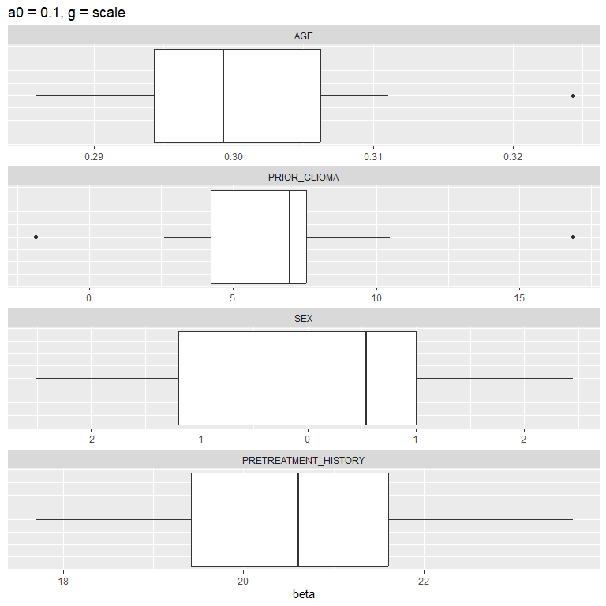

```r
plot(multiomics_cv)
```

Example on `BayesMultiomicsPriorSensitivity`

```r
# params
M <- GBM_data2$M
G <- GBM_data2$G
fp <- system.file("eg_fx_classification.txt", package="BayesMultiomics") # replace with your own file path
gene_grouping <- DAVIDGeneGrouping(eg_gene_symbols, fp)
Y <- GBM_data2$Y
C <- GBM_data2$C
Delta <- GBM_data2$Delta

a0 <- c(0.1, 1, 10, 50)
g <- list("scale", 1)
# run
multiomics_sensitivity <- BayesMultiomicsPriorSensitivity(
  M=M,
  G=G,
  grouping=gene_grouping,
  Y=Y,
  C=C,
  a0_vec=a0,
  gstr_vec=g,
  Delta=Delta,
  n_fold=10,
  random_seed = 123,
  EMVS_I = 10,
  NEG_I=20,
  EMVS_thresh = 0.0001,
  NEG_thresh = 0.0001
  )
```

```r
# summary
summary(multiomics_sensitivity)
```

```
#>   prior_a prior_g n_selected_vars          r2_train            r2_test      cindex_train
#> 1     0.1   scale             4.6         0.4447344          0.2356311         0.6039121
#> 2       1   scale             1.1         0.2991569          0.1990819         0.5922399
#> 3      10   scale               0        0.07660568           0.122488         0.4563015
#> 4      50   scale               0        0.07451221          0.2098255         0.4554439
#> 5     0.1       1           118.9 0.999343717229321 0.0800674836910385   0.9837261876608
#> 6       1       1           121.6 0.999047150484328 0.0502086799757693 0.980774979851593
#> 7      10       1            37.3 0.704984112972391    0.2730726927321 0.700699992390505
#> 8      50       1            20.3 0.541417433237452  0.313521104075804 0.642882894698054
#>         cindex_test         mse_train         mse_test    AGE PRIOR_GLIOMA     SEX
#> 1         0.5511064           239.889         392.0899 0.2997       5.7464  0.3279
#> 2         0.5785714          308.6202         378.1863 0.2983       4.1700 -0.1551
#> 3         0.4386447          425.4618         478.5079 0.2656       9.6345  1.8045
#> 4         0.4431534            426.26          460.569 0.2656       9.6390  1.8383
#> 5 0.569041693600517  0.27915451801225 3013.61670468387 0.0202       0.4389 -0.2344
#> 6 0.545494505494506 0.414820698605696 2870.61906324078 0.0485      -0.0515 -0.4946
#> 7 0.567619047619048  130.465342405664 328.955405323725 0.3095       2.2420  1.7201
#> 8 0.576904761904762  201.074619892514 323.467369569342 0.3015       2.6215  1.1357
#>   PRETREATMENT_HISTORY
#> 1              21.1407
#> 2              26.6346
#> 3              32.2409
#> 4              32.1582
#> 5              -0.2063
#> 6               0.1087
#> 7              20.5210
#> 8              23.8527
```

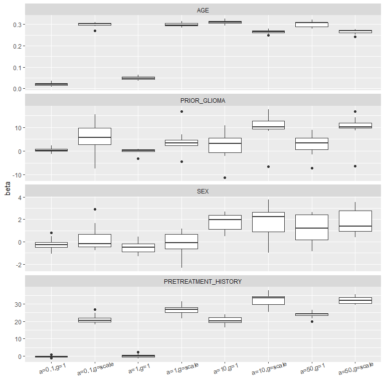

```r
plot(multiomics_sensitivity)
```